# Week 3 Assignment

Emma Colley

9/21/2020

# Redefining Variables

While I’ve kept my overall topic of rent burden in Massachusetts, I’ve made some small updates since last week. Instead of including people who spend 30% - 100% of their gross household income on monthly rent, I am now including all people who spend 0-100% of their gross household income on rent. I think this will give more depth to my findings below. Also, when examining the number of people in a household, I am capping the number at 10 people. There were a few outliers with 11, 12 and 13 people.

*Continuous*

1. Age of Individual (AGEP)
2. Number of People in Household (NP)
3. Annual Household Income (HINCP)
4. Gross Rent as Percentage of Household Income (GRPIP)

*Categorical*

1. Race/Ethnicity (RAC1P)
2. Highest Level of Education Received (SCHL)

## Loading Libraries

```r
library(tidycensus)
library(tidyverse)
library(ggplot2)
library(ggthemes)
```

## Loading Data

I am going to re-code the education level data to break it into fewer categories. I’ll attempt to use this later.

```r
person_data <- read_csv("rent_burden_massachusetts_v3.csv") %>%
mutate(EDU = case_when(
    SCHL_label=="1 or more years of college credit, no degree"~"GED or High School Diploma",
    SCHL_label=="12th grade - no diploma"~"No High School Diploma",
    SCHL_label=="Associate's degree"~"Associate's Degree",
    SCHL_label=="Bachelor's degree"~"Bachelor's Degree or Higher",
    SCHL_label=="Doctorate degree"~"Bachelor's Degree or Higher",
    SCHL_label=="GED or alternative credential"~"GED or High School Diploma",
    SCHL_label=="Grade 10"~"No High School Diploma",
    SCHL_label=="Grade 11"~"No High School Diploma",
    SCHL_label=="Grade 1"~"No High School Diploma",
    SCHL_label=="Grade 2"~"No High School Diploma",
    SCHL_label=="Grade 3"~"No High School Diploma",
    SCHL_label=="Grade 4"~"No High School Diploma",
    SCHL_label=="Grade 5"~"No High School Diploma",
    SCHL_label=="Grade 6"~"No High School Diploma",
    SCHL_label=="Grade 7"~"No High School Diploma",
    SCHL_label=="Grade 8"~"No High School Diploma",
    SCHL_label=="Grade 9"~"No High School Diploma",
    SCHL_label=="Kindergarten"~"No High School Diploma",
    SCHL_label=="Master's degree"~"Bachelor's Degree or Higher",
    SCHL_label=="No schooling completed"~"No High School Diploma",
    SCHL_label=="Nursery school, preschool"~"No High School Diploma",
    SCHL_label=="Professional degree beyond a bachelor's degree"~"Bachelor's Degree or Higher",
    SCHL_label=="Regular high school diploma"~"GED or High School Diploma",
    SCHL_label=="Some college, but less than 1 year"~"GED or High School Diploma"))
```

# Relationships between continuous variables that I’m interested In

Here are Pearson’s tests and accompanying figures of Gross Rent as a Percentage of Household Income compared to other variables.

## Age of Induvidual and Gross Rent as a Percentage of their Household Income

This correlation is weak but statistically significant. There is a slightly positive correlation at a 95% confidence level.

```r
correlation <- cor.test(person_data$AGEP, person_data$GRPIP)

correlation
```

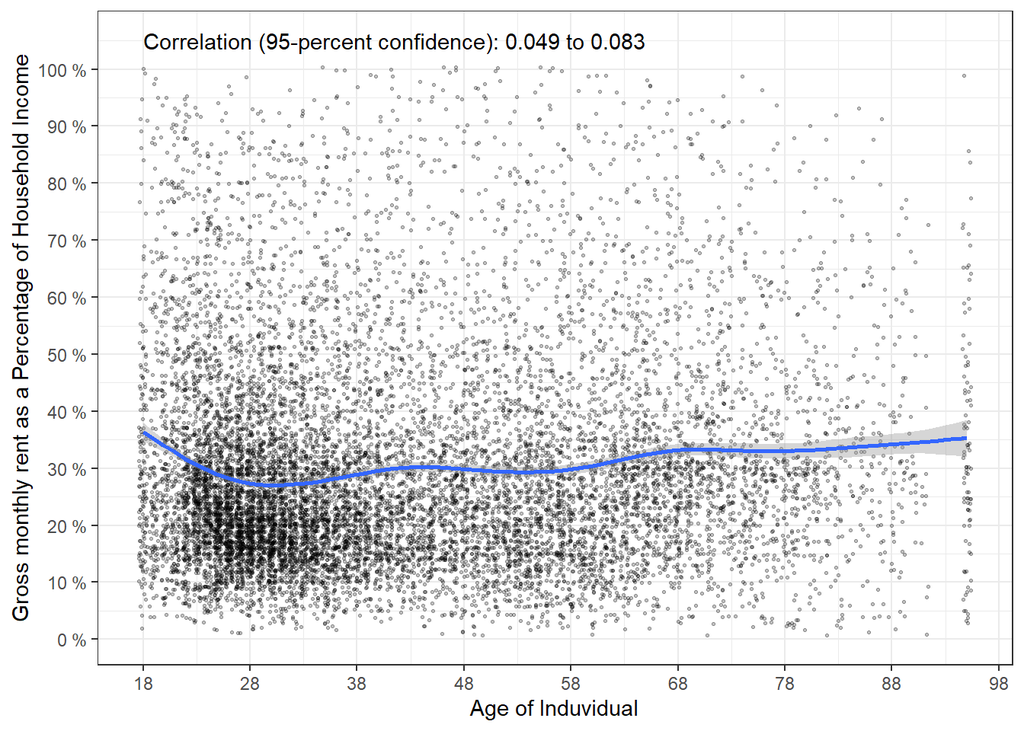

```r
ggplot(person_data, aes(x = AGEP, y = GRPIP)) +
  geom_point(size = 0.6, alpha = 0.25, position = "jitter") +
  geom_smooth() +
  theme_bw() +
  scale_x_continuous(name = "Age of Induvidual", breaks = seq(18, 100, by = 10)) +
  scale_y_continuous(name = "Gross monthly rent as a Percentage of Household Income",
                     breaks = seq(0, 100, by = 10),
                     labels = paste(prettyNum(seq(0, 100, by = 10)), "%")) +
  annotate(geom = "text", x = 18, y = 105,
           label = paste("Correlation (95-percent confidence):",
                         prettyNum(correlation$conf.int[1], digits = 2),
                         "to",
                         prettyNum(correlation$conf.int[2], digits = 2)),
           hjust = 0)
```

## Number of People in Household and Gross Rent as a Percentage of their Household Income

This correlation is weak but statistically significant. There is a negative correlation at a 95% confidence level.

```r
correlation <- cor.test(person_data$NP, person_data$GRPIP)

correlation
```

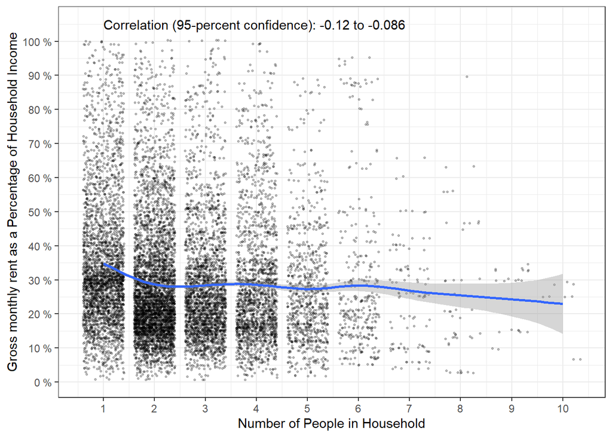

```r
ggplot(person_data, aes(x = NP, y = GRPIP)) +
  geom_point(size = 0.6, alpha = 0.25, position = "jitter") +
  geom_smooth() +
  theme_bw() +
  scale_x_continuous(name = "Number of People in Household", breaks = seq(1, 10, by = 1)) +
  scale_y_continuous(name = "Gross monthly rent as a Percentage of Household Income",
                     breaks = seq(0, 100, by = 10),
                     labels = paste(prettyNum(seq(0, 100, by = 10)), "%")) +
  annotate(geom = "text", x = 1, y = 105,
           label = paste("Correlation (95-percent confidence):",
                         prettyNum(correlation$conf.int[1], digits = 2),
                         "to",
                         prettyNum(correlation$conf.int[2], digits = 2)),
           hjust = 0)
```

## Household Income and Gross Rent as a Percentage of Household Income

This correlation is only moderate (around 0.5) but statistically significant. There is a negative correlation at a 95% confidence level.

```r
correlation <- cor.test(person_data$HINCP, person_data$GRPIP)

correlation
```

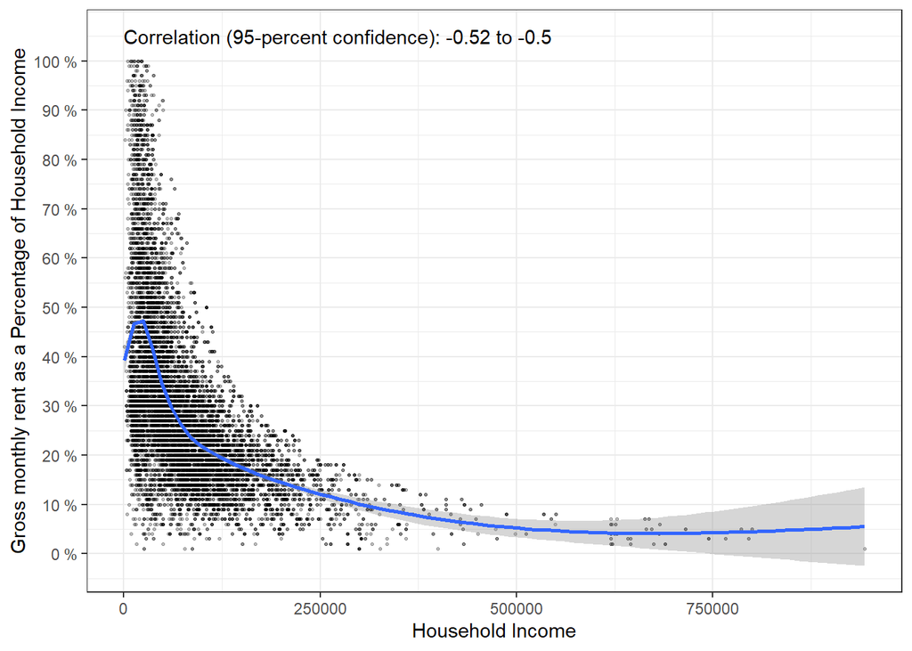

```r
ggplot(person_data, aes(x = HINCP, y = GRPIP)) +
  geom_point(size = 0.6, alpha = 0.25) +
  geom_smooth() +
  theme_bw() +
  scale_x_continuous(name = "Household Income") +
  scale_y_continuous(name = "Gross monthly rent as a Percentage of Household Income",
                     breaks = seq(0, 100, by = 10),
                     labels = paste(prettyNum(seq(0, 100, by = 10)), "%")) +
  annotate(geom = "text", x = 0, y = 105,
           label = paste("Correlation (95-percent confidence):",
                         prettyNum(correlation$conf.int[1], digits = 2),
                         "to",
                         prettyNum(correlation$conf.int[2], digits = 2)),
           hjust = 0)
```

# Other relationships between two continuous variables

Here are Pearson’s tests of other continuous variables that aren’t GRPIP.

## Age of Induvidal and Number of People in their Household

This correlation is weak (around 0.3) and statistically significant. There is a negative correlation at a 95% confidence level.

```r
correlation <- cor.test(person_data$AGEP, person_data$NP)

correlation
```

## Age of Induvidal and their Household Income

This correlation is weak but statistically significant. There is a negative correlation at a 95% confidence level.

```r
correlation <- cor.test(person_data$AGEP, person_data$HINCP)

correlation
```

# Relationships between a continuous variable and a binary variable that I’m interested in

Here are Two Sample t-tests and accompanying figures for Gross Rent as a Percentage of Household Income and binary variables.

## Gross Rent as Percentage of Household Income and Education Level

Are people with a Bachelor’s Degree less likely to live in rent burdened households?

There is a significant relationship between these two variables. We can be 95% confident that people in this sample set with a four-year college degree (Bachelor’s or higher) live in households that pay 5% - 6% less of their income on rent than those without a Bachelor’s degree. It looks like many people with a college degree live in households that pay less than 20% of their income on rent.

```r
difference = t.test(GRPIP ~ EDU == "Bachelor's Degree or Higher",
                    data = person_data)

difference
```

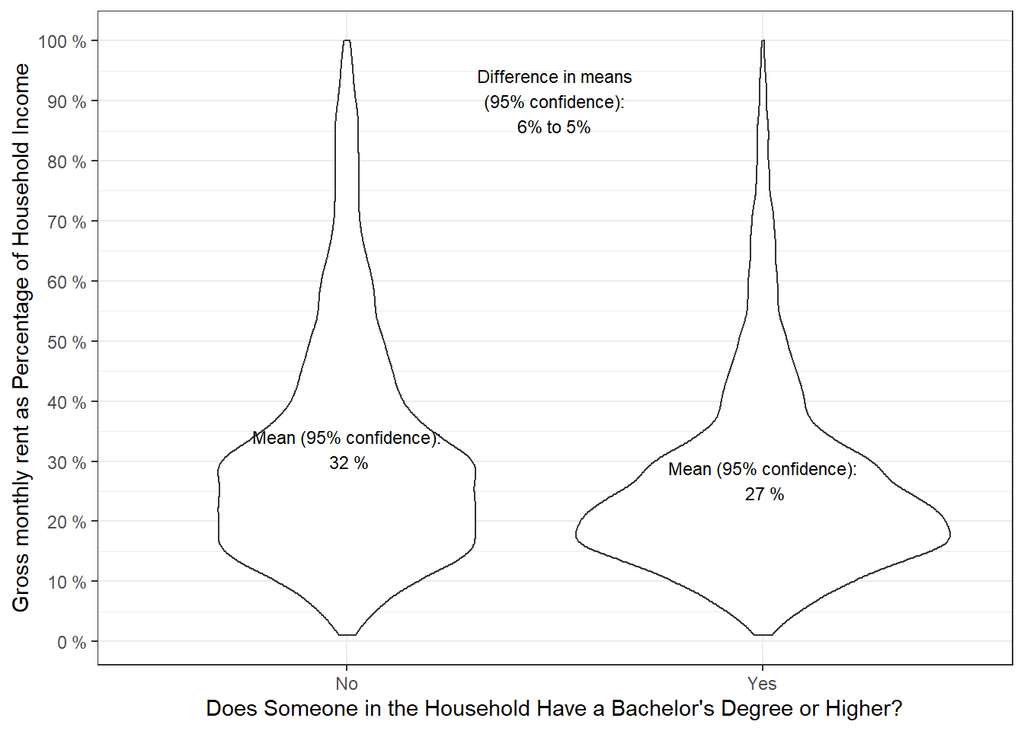

```r
ggplot(person_data, aes(x = EDU == "Bachelor's Degree or Higher", y = GRPIP)) +
  geom_violin() +
  theme_bw() +
  scale_x_discrete(name = "Does Someone in the Household Have a Bachelor's Degree or Higher?",
                   labels = c("No", "Yes")) +
   scale_y_continuous(name = "Gross monthly rent as Percentage of Household Income",
                     breaks = seq(0, 100, by = 10),
                     labels = paste(prettyNum(seq(0, 100, by = 10)), "%")) +
  annotate(geom = "text", x = 1.5, y = 90, size = 3,
           label = paste("Difference in means\n(95% confidence):\n",
                         prettyNum(abs(difference$conf.int[2]),
                                   digits = 0), "% to ",
                         prettyNum(abs(difference$conf.int[1]),
                                   digits = 0), "%",
                         sep = "")) +
  annotate(geom = "text", x = 1, y = difference$estimate[1], size = 3,
           label = paste("Mean (95% confidence):\n",
                         prettyNum(difference$estimate[1], digits = 0), "%")) +
  annotate(geom = "text", x = 2, y = difference$estimate[2], size = 3,
           label = paste("Mean (95% confidence):\n",
                         prettyNum(difference$estimate[2], digits = 0), "%"))
```

## Gross Rent as Percentage of Household Income and Race

There is a significant relationship between these two variables. We can be 95% confident that households with at least one person who is white that pay 2% - 3% less of their income on rent than non-white households. Again, many more household with at least one white person pay less than 20% of their income on rent. I thought this would be slightly more but I am not defining entirely white vs. entirely non-white households at this time.

```r
difference = t.test(GRPIP ~ RAC1P_label == "White alone",
                    data = person_data)

difference
```

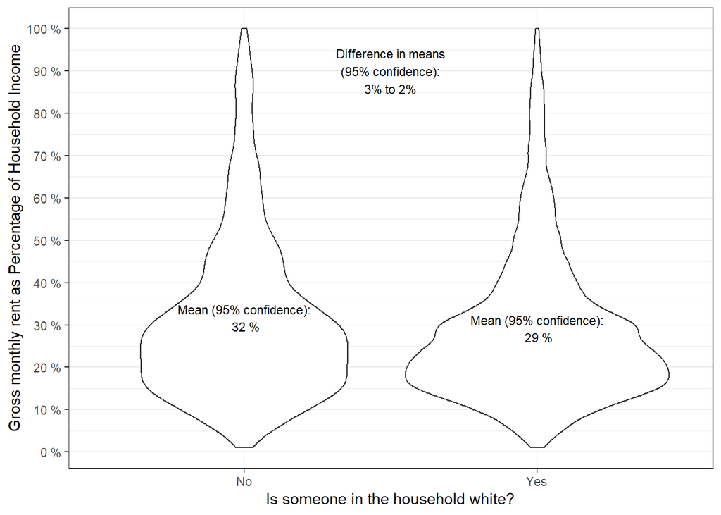

```r
ggplot(person_data, aes(x = RAC1P_label == "White alone", y = GRPIP)) +
  geom_violin() +
  theme_bw() +
  scale_x_discrete(name = "Is someone in the household white?",
                   labels = c("No", "Yes")) +
   scale_y_continuous(name = "Gross monthly rent as Percentage of Household Income",
                     breaks = seq(0, 100, by = 10),
                     labels = paste(prettyNum(seq(0, 100, by = 10)), "%")) +
  annotate(geom = "text", x = 1.5, y = 90, size = 3,
           label = paste("Difference in means\n(95% confidence):\n",
                         prettyNum(abs(difference$conf.int[2]),
                                   digits = 0), "% to ",
                         prettyNum(abs(difference$conf.int[1]),
                                   digits = 0), "%",
                         sep = "")) +
  annotate(geom = "text", x = 1, y = difference$estimate[1], size = 3,
           label = paste("Mean (95% confidence):\n",
                         prettyNum(difference$estimate[1], digits = 0), "%")) +
  annotate(geom = "text", x = 2, y = difference$estimate[2], size = 3,
           label = paste("Mean (95% confidence):\n",
                         prettyNum(difference$estimate[2], digits = 0), "%"))
```

# Relationship between a continuous variable and a categorical variable (three or more levels) that I’m interested in

here are ANOVA test and accompanying figures for Gross Rent as a Percentage of Household Income and categorical variables.

## Gross Rent as Percentage of Household Income and Race

There is a significant relationships between an individual’s race and their rent as a gross percentage of their household income.

```r
anova <- aov(GRPIP ~ RAC1P_label, data = person_data)

summary(anova)
```

```r
differences <- TukeyHSD(anova)

as_tibble(cbind(pair = row.names(differences$RAC1P),
                differences$RAC1P))
```

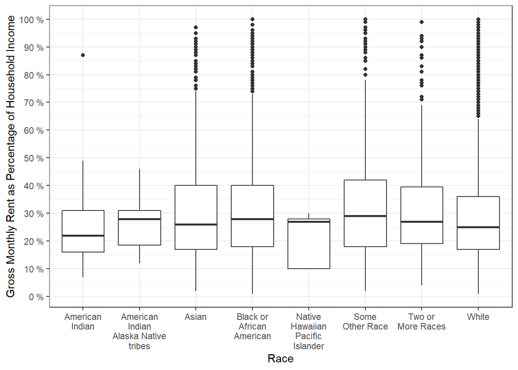

```r
ggplot(person_data, aes(x = RAC1P_label, y = GRPIP)) +
  geom_boxplot() +
  theme_bw() +
  scale_x_discrete(name = "Race", labels = c("American\nIndian",
                            "American\nIndian\nAlaska Native\ntribes",
                            "Asian",
                            "Black or\nAfrican\nAmerican",
                            "Native\nHawaiian\nPacific\nIslander",
                            "Some\nOther Race",
                            "Two or\nMore Races",
                            "White")) +

  scale_y_continuous(name = "Gross Monthly Rent as Percentage of Household Income",
                     breaks = seq(0, 100, by = 10),
                     labels = paste(prettyNum(seq(0, 100, by = 10)), "%"))
```

# Other relationships between continuous variables and categorical variables (three or more levels)

Here are ANOVA tests for continuous and categorical variables that don’t include GRPIP.

## Race of an Induvidual and Their Household Income

There is a significant relationships between an individual’s race and their household income.

```r
anova <- aov(HINCP ~ RAC1P_label, data = person_data)

summary(anova)
```

```
##                Df    Sum Sq   Mean Sq F value Pr(>F)
## RAC1P_label     7 1.087e+12 1.553e+11   25.61 <2e-16 ***
## Residuals   13145 7.974e+13 6.066e+09
## ---
## Signif. codes:  0 '***' 0.001 '**' 0.01 '*' 0.05 '.' 0.1 ' ' 1
```

```r
differences <- TukeyHSD(anova)

as_tibble(cbind(pair = row.names(differences$RAC1P),
                differences$RAC1P))
```

```
## # A tibble: 28 x 5
##    pair                               diff       lwr        upr       `p adj`
##    <chr>                              <chr>      <chr>      <chr>     <chr>
##  1 American Indian and Alaska Native~ -42753.94~ -143713.2~ 58205.37~ 0.9051398~
##  2 Asian alone-American Indian alone  17228.890~ -30561.22~ 65019.00~ 0.9584928~
##  3 Black or African American alone-A~ -13417.68~ -61097.41~ 34262.04~ 0.9899160~
##  4 Native Hawaiian and Other Pacific~ 31383.199~ -84280.23~ 147046.6~ 0.9919051~
##  5 Some Other Race alone-American In~ -21736.58~ -69660.99~ 26187.83~ 0.8688624~
##  6 Two or More Races-American Indian~ -6565.221~ -55011.30~ 41880.85~ 0.9999100~
##  7 White alone-American Indian alone  3846.1566~ -43435.29~ 51127.60~ 0.9999972~
##  8 Asian alone-American Indian and A~ 59982.833~ -29556.74~ 149522.4~ 0.4609252~
##  9 Black or African American alone-A~ 29336.257~ -60144.45~ 118816.9~ 0.9754412~
## 10 Native Hawaiian and Other Pacific~ 74137.142~ -64107.10~ 212381.3~ 0.7348323~
## # ... with 18 more rows
```

## Level of Education of an Induvidual and Their Household Income

There is a significant relationships between an individual’s level of education and their household income.

```r
anova <- aov(HINCP ~ EDU, data = person_data)

summary(anova)
```

```
##                Df    Sum Sq   Mean Sq F value Pr(>F)
## EDU             3 1.034e+13 3.447e+12   643.2 <2e-16 ***
## Residuals   13149 7.048e+13 5.360e+09
## ---
## Signif. codes:  0 '***' 0.001 '**' 0.01 '*' 0.05 '.' 0.1 ' ' 1
```

```r
differences <- TukeyHSD(anova)

as_tibble(cbind(pair = row.names(differences$EDU),
                differences$EDU))
```

```
## # A tibble: 6 x 5
##   pair                          diff        lwr         upr        `p adj`
##   <chr>                         <chr>       <chr>       <chr>      <chr>
## 1 Bachelor's Degree or Higher-~ 44642.6691~ 37610.1914~ 51675.146~ 7.3669070843~
## 2 GED or High School Diploma-A~ -9041.6820~ -16090.453~ -1992.911~ 0.0054356968~
## 3 No High School Diploma-Assoc~ -23811.823~ -31841.117~ -15782.53~ 7.3856698534~
## 4 GED or High School Diploma-B~ -53684.351~ -57324.566~ -50044.13~ 7.3669070843~
## 5 No High School Diploma-Bache~ -68454.492~ -73749.353~ -63159.63~ 7.3669070843~
## 6 No High School Diploma-GED o~ -14770.141~ -20086.623~ -9453.659~ 7.9671602648~
```

# Relationship between two categorical variables

Here is a Chi-Square test.

## Race of An Induvidual and their Level of Education

For this data set of residents of Massachusetts, is there a relationship between an individuals race and their education level?

Note: I am receiving a notification that “Chi=squared approximation may be incorrect.” My classmate Megan Willis-Jackson explained to me this is because there are some race categories with very few observations.

There is a statistically significant relationship between an individual’s race and their level of education.

```r
chi_sq <- chisq.test(person_data$RAC1P_label, person_data$SCHL_label == "Master's degree")
chi_sq
```

```
##
##  Pearson's Chi-squared test
##
## data:  person_data$RAC1P_label and person_data$SCHL_label == "Master's degree"
## X-squared = 214.06, df = 7, p-value < 2.2e-16
```

```r
chi_sq$observed
```

```
##
## person_data$RAC1P_label                                                                                                     FALSE
##   American Indian alone                                                                                                        24
##   American Indian and Alaska Native tribes specified; or American Indian or Alaska Native, not specified and no other races     7
##   Asian alone                                                                                                                 813
##   Black or African American alone                                                                                            1200
##   Native Hawaiian and Other Pacific Islander alone                                                                              3
##   Some Other Race alone                                                                                                       815
##   Two or More Races                                                                                                           427
##   White alone                                                                                                                8374
##
## person_data$RAC1P_label                                                                                                     TRUE
##   American Indian alone                                                                                                        1
##   American Indian and Alaska Native tribes specified; or American Indian or Alaska Native, not specified and no other races    0
##   Asian alone                                                                                                                215
##   Black or African American alone                                                                                             76
##   Native Hawaiian and Other Pacific Islander alone                                                                             2
##   Some Other Race alone                                                                                                       16
##   Two or More Races                                                                                                           48
##   White alone                                                                                                               1132
```

```r
chi_sq$expected
```

```
##
## person_data$RAC1P_label                                                                                                           FALSE
##   American Indian alone                                                                                                       22.167946
##   American Indian and Alaska Native tribes specified; or American Indian or Alaska Native, not specified and no other races    6.207025
##   Asian alone                                                                                                                911.545959
##   Black or African American alone                                                                                           1131.451988
##   Native Hawaiian and Other Pacific Islander alone                                                                             4.433589
##   Some Other Race alone                                                                                                      736.862541
##   Two or More Races                                                                                                          421.190983
##   White alone                                                                                                               8429.139968
##
## person_data$RAC1P_label                                                                                                             TRUE
##   American Indian alone                                                                                                        2.8320535
##   American Indian and Alaska Native tribes specified; or American Indian or Alaska Native, not specified and no other races    0.7929750
##   Asian alone                                                                                                                116.4540409
##   Black or African American alone                                                                                            144.5480119
##   Native Hawaiian and Other Pacific Islander alone                                                                             0.5664107
##   Some Other Race alone                                                                                                       94.1374591
##   Two or More Races                                                                                                           53.8090170
##   White alone                                                                                                               1076.8600319
```